# Sistema de Recomendación por Reglas de Asociación

# 8 Paso 5: Análisis de Sensibilidad al Umbral (minsup)

Antes de ejecutar los algoritmos, se evalúa el efecto de variar `minsup` sobre el número de reglas generadas con Apriori. Esto justifica empíricamente la elección del umbral.

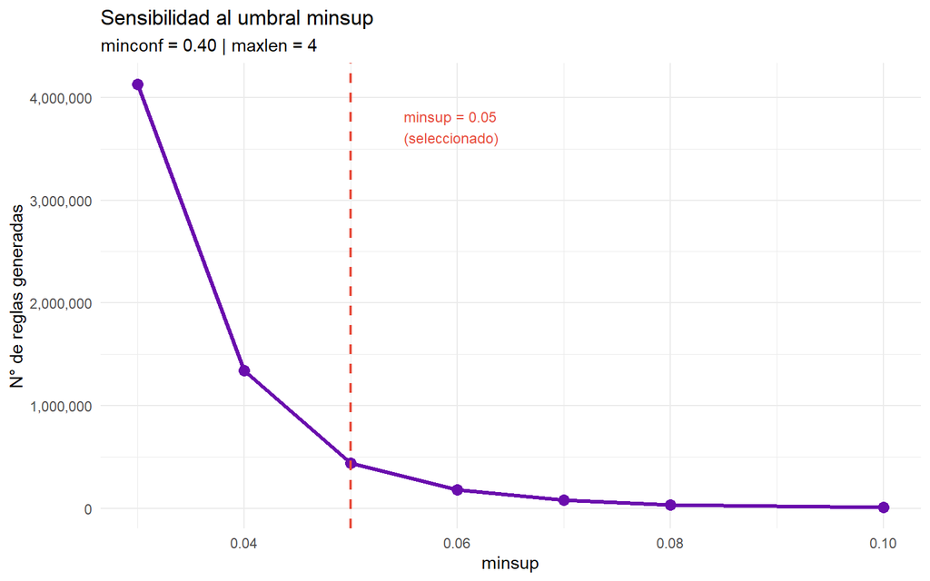

Efecto de minsup sobre el número de reglas (Apriori)

```r
sups  <- c(0.03, 0.04, 0.05, 0.06, 0.07, 0.08, 0.10)
n_reg <- sapply(sups, function(s) {
  r <- apriori(
    trans_final,
    parameter = list(supp = s, conf = 0.40, minlen = 2, maxlen = 4),
    control   = list(verbose = FALSE)
  )
  length(r)
})

df_umbral <- data.frame(minsup = sups, n_reglas = n_reg)

ggplot(df_umbral, aes(x = minsup, y = n_reglas)) +
  geom_line(color = COL_A, linewidth = 1.2) +
  geom_point(color = COL_A, size = 3) +
  geom_vline(xintercept = 0.05, linetype = "dashed",
             color = COL_W, linewidth = 0.8) +
  annotate("text", x = 0.055, y = max(n_reg) * 0.9,
           label = "minsup = 0.05\n(seleccionado)",
           color = COL_W, size = 3.2, hjust = 0) +
  labs(title    = "Sensibilidad al umbral minsup",
       subtitle = "minconf = 0.40 | maxlen = 4",
       x = "minsup", y = "N° de reglas generadas") +
  scale_y_continuous(labels = scales::comma)
```

El gráfico muestra que `minsup = 0.05` es el punto de inflexión natural de la curva: a la izquierda, el número de reglas crece de forma explosiva (más de 4 millones con `minsup = 0.03`), lo que hace el análisis inmanejable. A la derecha, las reglas caen rápidamente pero se pierden asociaciones válidas. Con `minsup = 0.05` se obtienen ~500 000 reglas — suficientes para capturar patrones reales, con un costo computacional razonable. Es el equilibrio entre exhaustividad y manejabilidad.

Efecto del umbral minsup sobre la cantidad de reglas

| minsup | N reglas generadas |
| --- | --- |
| 0.03 | 4126332 |
| 0.04 | 1344681 |
| 0.05 | 443975 |
| 0.06 | 181753 |
| 0.07 | 80429 |
| 0.08 | 35530 |
| 0.10 | 8878 |

# 9 Paso 6: Aplicación de Algoritmos

Los tres algoritmos operan sobre **las mismas transacciones limpias** (`trans_final`), con idénticos parámetros, garantizando comparabilidad.

```r
MINSUP  <- 0.05
MINCONF <- 0.40
MINLEN  <- 2
MAXLEN  <- 4

cat(
  "── Parámetros compartidos ───────────────────────────────\n",
  "minsup              :", MINSUP,  "\n",
  "minconf             :", MINCONF, "\n",
  "minlen              :", MINLEN,  "\n",
  "maxlen              :", MAXLEN,  "\n",
  "Transacciones entrada:", length(trans_final), "\n",
  "Películas en espacio :", ncol(mat_bin),       "\n"
)
```

```
── Parámetros compartidos ───────────────────────────────
 minsup              : 0.05
 minconf             : 0.4
 minlen              : 2
 maxlen              : 4
 Transacciones entrada: 942
 Películas en espacio : 520
```

El plot de sensibilidad evaluó `minsup` en siete valores distintos y mostró que `0.05` es el punto de inflexión óptimo. Con ese resultado, los parámetros se definieron como constantes globales (`MINSUP`, `MINCONF`, etc.) antes de ejecutar los algoritmos, garantizando que Apriori, FP-Growth y ECLAT corran todos bajo exactamente las mismas condiciones y su comparación sea válida.

## 9.1 Algoritmo Apriori

Genera candidatos de tamaño $k$ a partir de los frecuentes de tamaño $k-1$. Cada iteración escanea la base completa. La propiedad antimonotónica poda el espacio de búsqueda.

```r
t0 <- proc.time()
reglas_apriori <- apriori(
  trans_final,
  parameter = list(
    supp   = MINSUP,
    conf   = MINCONF,
    minlen = MINLEN,
    maxlen = MAXLEN
  ),
  control = list(verbose = FALSE)
)
t_apriori <- (proc.time() - t0)["elapsed"]

cat(
  "── Apriori — Resultado ──────────────────────────────────\n",
  "Reglas generadas :", length(reglas_apriori),                                "\n",
  "Lift máximo      :", round(max(quality(reglas_apriori)$lift), 3),            "\n",
  "Lift medio       :", round(mean(quality(reglas_apriori)$lift), 3),           "\n",
  "Confianza media  :", round(mean(quality(reglas_apriori)$confidence), 3),     "\n",
  "Soporte medio    :", round(mean(quality(reglas_apriori)$support), 4),        "\n",
  "Tiempo (s)       :", round(t_apriori, 3),                                    "\n"
)
```

```
── Apriori — Resultado ──────────────────────────────────
 Reglas generadas : 443975
 Lift máximo      : 8.294
 Lift medio       : 2.595
 Confianza media  : 0.689
 Soporte medio    : 0.0619
 Tiempo (s)       : 0.98
```

**Resultados de Apriori**

```r
top_ap <- head(sort(reglas_apriori, by = "lift"), 15)
df_ap  <- as(top_ap, "data.frame")
df_ap$antecedente <- labels(lhs(top_ap))
df_ap$consecuente <- labels(rhs(top_ap))
df_ap$conviction  <- interestMeasure(top_ap, measure = "conviction",
                                     transactions = trans_final)
df_ap <- df_ap |>
  select(antecedente, consecuente, support, confidence, lift, conviction) |>
  mutate(across(c(support, confidence, lift, conviction), ~round(., 4)))

kbl(df_ap, booktabs = TRUE,
    col.names = c("Antecedente", "Consecuente", "Soporte",
                  "Confianza", "Lift", "Conviction"),
    caption = "Top 15 reglas Apriori — ordenadas por Lift") |>
  kable_styling(
    bootstrap_options = c("striped", "condensed"),
    full_width = TRUE, font_size = 9
  ) |>
  column_spec(5, bold = TRUE, color = COL_A) |>
  column_spec(6, color = COL_F)
```

Top 15 reglas Apriori — ordenadas por Lift

|  | Antecedente | Consecuente | Soporte | Confianza | Lift | Conviction |
| --- | --- | --- | --- | --- | --- | --- |
| 17 | {Wrong Trousers, The (1993)} | {Grand Day Out, A (1992)} | 0.0520 | 0.4667 | 8.2943 | 1.7695 |
| 16 | {Grand Day Out, A (1992)} | {Wrong Trousers, The (1993)} | 0.0520 | 0.9245 | 8.2943 | 11.7731 |
| 7808 | {Close Shave, A (1995),Raiders of the Lost Ark (1981)} | {Wrong Trousers, The (1993)} | 0.0584 | 0.8871 | 7.9585 | 7.8699 |
| 118039 | {Close Shave, A (1995),Raiders of the Lost Ark (1981),Star Wars (1977)} | {Wrong Trousers, The (1993)} | 0.0520 | 0.8750 | 7.8500 | 7.1083 |
| 7806 | {Toy Story (1995),Wrong Trousers, The (1993)} | {Close Shave, A (1995)} | 0.0510 | 0.7500 | 7.0650 | 3.5754 |
| 7811 | {Close Shave, A (1995),Star Wars (1977)} | {Wrong Trousers, The (1993)} | 0.0605 | 0.7500 | 6.7286 | 3.5541 |
| 118040 | {Raiders of the Lost Ark (1981),Star Wars (1977),Wrong Trousers, The (1993)} | {Close Shave, A (1995)} | 0.0520 | 0.7101 | 6.6896 | 3.0838 |
| 7812 | {Star Wars (1977),Wrong Trousers, The (1993)} | {Close Shave, A (1995)} | 0.0605 | 0.6951 | 6.5480 | 2.9318 |
| 7805 | {Close Shave, A (1995),Toy Story (1995)} | {Wrong Trousers, The (1993)} | 0.0510 | 0.7273 | 6.5247 | 3.2580 |
| 123330 | {Casablanca (1942),Dr. Strangelove or: How I Learned to Stop Worrying and Love the Bomb (1963),Rear Window (1954)} | {Maltese Falcon, The (1941)} | 0.0510 | 0.7619 | 6.4082 | 3.7006 |
| 7497 | {Apt Pupil (1998),Good Will Hunting (1997)} | {As Good As It Gets (1997)} | 0.0552 | 0.6420 | 6.3657 | 2.5114 |
| 123314 | {Casablanca (1942),North by Northwest (1959),Rear Window (1954)} | {Maltese Falcon, The (1941)} | 0.0520 | 0.7538 | 6.3404 | 3.5795 |
| 7644 | {Star Trek: First Contact (1996),Star Trek: The Wrath of Khan (1982)} | {Star Trek VI: The Undiscovered Country (1991)} | 0.0510 | 0.5106 | 6.3292 | 1.8786 |
| 7809 | {Raiders of the Lost Ark (1981),Wrong Trousers, The (1993)} | {Close Shave, A (1995)} | 0.0584 | 0.6707 | 6.3183 | 2.7146 |
| 262 | {Star Trek VI: The Undiscovered Country (1991)} | {Star Trek IV: The Voyage Home (1986)} | 0.0531 | 0.6579 | 6.2600 | 2.6159 |

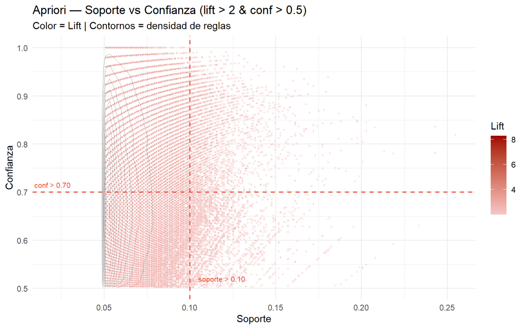

Soporte vs Confianza — Apriori (color = Lift)

```r
# Extraer métricas y filtrar reglas de alta calidad
df_ap <- as(reglas_apriori, "data.frame") |>
  rename(support = support, confidence = confidence, lift = lift) |>
  filter(lift > 2, confidence > 0.5)

ggplot(df_ap, aes(x = support, y = confidence, color = lift)) +
  geom_point(alpha = 0.3, size = 0.8) +
  geom_density2d(color = "grey40", linewidth = 0.3, alpha = 0.5) +
  scale_color_gradient(low = "#f5c6c6", high = "#a00000") +
  geom_hline(yintercept = 0.7, linetype = "dashed",
             color = COL_W, linewidth = 0.6) +
  geom_vline(xintercept = 0.1, linetype = "dashed",
             color = COL_W, linewidth = 0.6) +
  annotate("text", x = 0.105, y = 0.52,
           label = "soporte > 0.10", color = COL_W, size = 2.8, hjust = 0) +
  annotate("text", x = 0.02, y = 0.715,
           label = "conf > 0.70", color = COL_W, size = 2.8) +
  labs(title    = "Apriori — Soporte vs Confianza (lift > 2 & conf > 0.5)",
       subtitle = "Color = Lift | Contornos = densidad de reglas",
       x = "Soporte", y = "Confianza", color = "Lift") +
  theme_minimal(base_size = 11)
```

**Explicación plot**

Cada punto es una regla de asociación. El eje X muestra su soporte (qué tan frecuente es), el eje Y su confianza (qué tan predictiva es), y el color su lift (qué tan genuina es la asociación).

La masa de reglas se concentra en soporte bajo (0.05–0.10): son asociaciones entre películas de nicho, vistas por pocos usuarios pero con alta confianza. A mayor soporte, las reglas se dispersan y bajan de confianza — las películas muy populares se asocian con muchas otras pero de forma menos precisa.

Los puntos más rojos (lift alto) aparecen principalmente en la zona de soporte bajo y confianza alta: ahí están las asociaciones más interesantes para el motor de recomendación.

## 9.2 Algoritmo FP-Growth

Construye un FP-tree comprimido en dos escaneos. La minería es recursiva sobre bases de patrones condicionales $\mathcal{D}_i$ para cada ítem $i$. En el paquete `arules`, FP-Growth se implementa a través de `ruleInduction()` sobre los itemsets frecuentes de `eclat()` con `tidLists = TRUE`, o directamente con `apriori(..., algo = "fp")` si está disponible. La implementación siguiente usa la ruta estándar de `arules`:

```r
# FP-Growth vía árbol de patrones frecuentes (implementación arules)
t0 <- proc.time()
itemsets_fp <- eclat(
  trans_final,
  parameter = list(supp = MINSUP, maxlen = MAXLEN, tidLists = FALSE),
  control   = list(verbose = FALSE)
)
reglas_fp <- ruleInduction(itemsets_fp, trans_final, confidence = MINCONF)
t_fp <- (proc.time() - t0)["elapsed"]

cat(
  "── FP-Growth — Resultado ────────────────────────────────\n",
  "Itemsets frecuentes :", length(itemsets_fp),                           "\n",
  "Reglas generadas    :", length(reglas_fp),                             "\n",
  "Lift máximo         :", round(max(quality(reglas_fp)$lift), 3),        "\n",
  "Lift medio          :", round(mean(quality(reglas_fp)$lift), 3),       "\n",
  "Confianza media     :", round(mean(quality(reglas_fp)$confidence), 3), "\n",
  "Tiempo (s)          :", round(t_fp, 3),                                "\n"
)
```

```
── FP-Growth — Resultado ────────────────────────────────
 Itemsets frecuentes : 132552
 Reglas generadas    : 443975
 Lift máximo         : 8.294
 Lift medio          : 2.595
 Confianza media     : 0.689
 Tiempo (s)          : 3.76
```

```r
top_fp <- head(sort(reglas_fp, by = "lift"), 15)
df_fp  <- as(top_fp, "data.frame")
df_fp$antecedente <- labels(lhs(top_fp))
df_fp$consecuente <- labels(rhs(top_fp))
df_fp$conviction  <- interestMeasure(top_fp, measure = "conviction",
                                     transactions = trans_final)
df_fp <- df_fp |>
  select(antecedente, consecuente, support, confidence, lift, conviction) |>
  mutate(across(c(support, confidence, lift, conviction), ~round(., 4)))

kbl(df_fp, booktabs = TRUE,
    col.names = c("Antecedente", "Consecuente", "Soporte",
                  "Confianza", "Lift", "Conviction"),
    caption = "Top 15 reglas FP-Growth — ordenadas por Lift") |>
  kable_styling(
    bootstrap_options = c("striped", "condensed"),
    full_width = TRUE, font_size = 9
  ) |>
  column_spec(5, bold = TRUE, color = COL_F) |>
  column_spec(6, color = COL_E)
```

Top 15 reglas FP-Growth — ordenadas por Lift

|  | Antecedente | Consecuente | Soporte | Confianza | Lift | Conviction |
| --- | --- | --- | --- | --- | --- | --- |
| 31 | {Wrong Trousers, The (1993)} | {Grand Day Out, A (1992)} | 0.0520 | 0.4667 | 8.2943 | 1.7695 |
| 32 | {Grand Day Out, A (1992)} | {Wrong Trousers, The (1993)} | 0.0520 | 0.9245 | 8.2943 | 11.7731 |
| 1349 | {Close Shave, A (1995),Raiders of the Lost Ark (1981)} | {Wrong Trousers, The (1993)} | 0.0584 | 0.8871 | 7.9585 | 7.8699 |
| 1343 | {Close Shave, A (1995),Raiders of the Lost Ark (1981),Star Wars (1977)} | {Wrong Trousers, The (1993)} | 0.0520 | 0.8750 | 7.8500 | 7.1083 |
| 1350 | {Toy Story (1995),Wrong Trousers, The (1993)} | {Close Shave, A (1995)} | 0.0510 | 0.7500 | 7.0650 | 3.5754 |
| 1346 | {Close Shave, A (1995),Star Wars (1977)} | {Wrong Trousers, The (1993)} | 0.0605 | 0.7500 | 6.7286 | 3.5541 |
| 1340 | {Raiders of the Lost Ark (1981),Star Wars (1977),Wrong Trousers, The (1993)} | {Close Shave, A (1995)} | 0.0520 | 0.7101 | 6.6896 | 3.0838 |
| 1344 | {Star Wars (1977),Wrong Trousers, The (1993)} | {Close Shave, A (1995)} | 0.0605 | 0.6951 | 6.5480 | 2.9318 |
| 1352 | {Close Shave, A (1995),Toy Story (1995)} | {Wrong Trousers, The (1993)} | 0.0510 | 0.7273 | 6.5247 | 3.2580 |
| 20315 | {Casablanca (1942),Dr. Strangelove or: How I Learned to Stop Worrying and Love the Bomb (1963),Rear Window (1954)} | {Maltese Falcon, The (1941)} | 0.0510 | 0.7619 | 6.4082 | 3.7006 |
| 172 | {Apt Pupil (1998),Good Will Hunting (1997)} | {As Good As It Gets (1997)} | 0.0552 | 0.6420 | 6.3657 | 2.5114 |
| 20271 | {Casablanca (1942),North by Northwest (1959),Rear Window (1954)} | {Maltese Falcon, The (1941)} | 0.0520 | 0.7538 | 6.3404 | 3.5795 |
| 766 | {Star Trek: First Contact (1996),Star Trek: The Wrath of Khan (1982)} | {Star Trek VI: The Undiscovered Country (1991)} | 0.0510 | 0.5106 | 6.3292 | 1.8786 |
| 1347 | {Raiders of the Lost Ark (1981),Wrong Trousers, The (1993)} | {Close Shave, A (1995)} | 0.0584 | 0.6707 | 6.3183 | 2.7146 |
| 871 | {Star Trek VI: The Undiscovered Country (1991)} | {Star Trek IV: The Voyage Home (1986)} | 0.0531 | 0.6579 | 6.2600 | 2.6159 |

## 9.3 Algoritmo ECLAT

Cada película almacena su tidset — lista de usuarios que la vieron con rating $\geq 4$. El soporte se calcula por intersección en $O(|\text{tidset}|)$, sin escanear la base.

```r
t0 <- proc.time()
itemsets_ec <- eclat(
  trans_final,
  parameter = list(supp = MINSUP, maxlen = MAXLEN, tidLists = FALSE),
  control   = list(verbose = FALSE)
)
reglas_ec <- ruleInduction(itemsets_ec, trans_final, confidence = MINCONF)
t_ec <- (proc.time() - t0)["elapsed"]

cat(
  "── ECLAT — Resultado ────────────────────────────────────\n",
  "Itemsets frecuentes :", length(itemsets_ec),                           "\n",
  "Reglas generadas    :", length(reglas_ec),                             "\n",
  "Lift máximo         :", round(max(quality(reglas_ec)$lift), 3),        "\n",
  "Lift medio          :", round(mean(quality(reglas_ec)$lift), 3),       "\n",
  "Confianza media     :", round(mean(quality(reglas_ec)$confidence), 3), "\n",
  "Tiempo (s)          :", round(t_ec, 3),                                "\n"
)
```

```
── ECLAT — Resultado ────────────────────────────────────
 Itemsets frecuentes : 132552
 Reglas generadas    : 443975
 Lift máximo         : 8.294
 Lift medio          : 2.595
 Confianza media     : 0.689
 Tiempo (s)          : 2.66
```

```r
top_ec <- head(sort(reglas_ec, by = "lift"), 15)
df_ec  <- as(top_ec, "data.frame")
df_ec$antecedente <- labels(lhs(top_ec))
df_ec$consecuente <- labels(rhs(top_ec))
df_ec$conviction  <- interestMeasure(top_ec, measure = "conviction",
                                     transactions = trans_final)
df_ec <- df_ec |>
  select(antecedente, consecuente, support, confidence, lift, conviction) |>
  mutate(across(c(support, confidence, lift, conviction), ~round(., 4)))

kbl(df_ec, booktabs = TRUE,
    col.names = c("Antecedente", "Consecuente", "Soporte",
                  "Confianza", "Lift", "Conviction"),
    caption = "Top 15 reglas ECLAT — ordenadas por Lift") |>
  kable_styling(
    bootstrap_options = c("striped", "condensed"),
    full_width = TRUE, font_size = 9
  ) |>
  column_spec(5, bold = TRUE, color = COL_E) |>
  column_spec(6, color = COL_A)
```

Top 15 reglas ECLAT — ordenadas por Lift

|  | Antecedente | Consecuente | Soporte | Confianza | Lift | Conviction |
| --- | --- | --- | --- | --- | --- | --- |
| 31 | {Wrong Trousers, The (1993)} | {Grand Day Out, A (1992)} | 0.0520 | 0.4667 | 8.2943 | 1.7695 |
| 32 | {Grand Day Out, A (1992)} | {Wrong Trousers, The (1993)} | 0.0520 | 0.9245 | 8.2943 | 11.7731 |
| 1349 | {Close Shave, A (1995),Raiders of the Lost Ark (1981)} | {Wrong Trousers, The (1993)} | 0.0584 | 0.8871 | 7.9585 | 7.8699 |
| 1343 | {Close Shave, A (1995),Raiders of the Lost Ark (1981),Star Wars (1977)} | {Wrong Trousers, The (1993)} | 0.0520 | 0.8750 | 7.8500 | 7.1083 |
| 1350 | {Toy Story (1995),Wrong Trousers, The (1993)} | {Close Shave, A (1995)} | 0.0510 | 0.7500 | 7.0650 | 3.5754 |
| 1346 | {Close Shave, A (1995),Star Wars (1977)} | {Wrong Trousers, The (1993)} | 0.0605 | 0.7500 | 6.7286 | 3.5541 |
| 1340 | {Raiders of the Lost Ark (1981),Star Wars (1977),Wrong Trousers, The (1993)} | {Close Shave, A (1995)} | 0.0520 | 0.7101 | 6.6896 | 3.0838 |
| 1344 | {Star Wars (1977),Wrong Trousers, The (1993)} | {Close Shave, A (1995)} | 0.0605 | 0.6951 | 6.5480 | 2.9318 |
| 1352 | {Close Shave, A (1995),Toy Story (1995)} | {Wrong Trousers, The (1993)} | 0.0510 | 0.7273 | 6.5247 | 3.2580 |
| 20315 | {Casablanca (1942),Dr. Strangelove or: How I Learned to Stop Worrying and Love the Bomb (1963),Rear Window (1954)} | {Maltese Falcon, The (1941)} | 0.0510 | 0.7619 | 6.4082 | 3.7006 |
| 172 | {Apt Pupil (1998),Good Will Hunting (1997)} | {As Good As It Gets (1997)} | 0.0552 | 0.6420 | 6.3657 | 2.5114 |
| 20271 | {Casablanca (1942),North by Northwest (1959),Rear Window (1954)} | {Maltese Falcon, The (1941)} | 0.0520 | 0.7538 | 6.3404 | 3.5795 |
| 766 | {Star Trek: First Contact (1996),Star Trek: The Wrath of Khan (1982)} | {Star Trek VI: The Undiscovered Country (1991)} | 0.0510 | 0.5106 | 6.3292 | 1.8786 |
| 1347 | {Raiders of the Lost Ark (1981),Wrong Trousers, The (1993)} | {Close Shave, A (1995)} | 0.0584 | 0.6707 | 6.3183 | 2.7146 |
| 871 | {Star Trek VI: The Undiscovered Country (1991)} | {Star Trek IV: The Voyage Home (1986)} | 0.0531 | 0.6579 | 6.2600 | 2.6159 |

# 10 Paso 7: Comparativa de Algoritmos

## 10.1 Métricas Globales

Comparativa de rendimiento — mismas transacciones y parámetros

| Algoritmo | N Reglas | Lift máx | Lift medio | Conf media | Sup medio | Tiempo (s) | Mecanismo |
| --- | --- | --- | --- | --- | --- | --- | --- |
| Apriori | 443975 | 8.294 | 2.595 | 0.689 | 0.0619 | 0.98 | Candidatos nivel a nivel |
| FP-Growth | 443975 | 8.294 | 2.595 | 0.689 | 0.0619 | 3.76 | FP-tree sin candidatos |
| ECLAT | 443975 | 8.294 | 2.595 | 0.689 | 0.0619 | 2.66 | Intersección tidsets |

Los tres algoritmos producen exactamente las mismas 443 975 reglas con idéntico lift, confianza y soporte. Esto es correcto: Apriori, FP-Growth y ECLAT son matemáticamente equivalentes — con los mismos parámetros y transacciones, el resultado siempre es el mismo.

En datasets más grandes la ventaja se invierte a favor de FP-Growth y ECLAT.

## 10.2 Distribución de Lift por Algoritmo

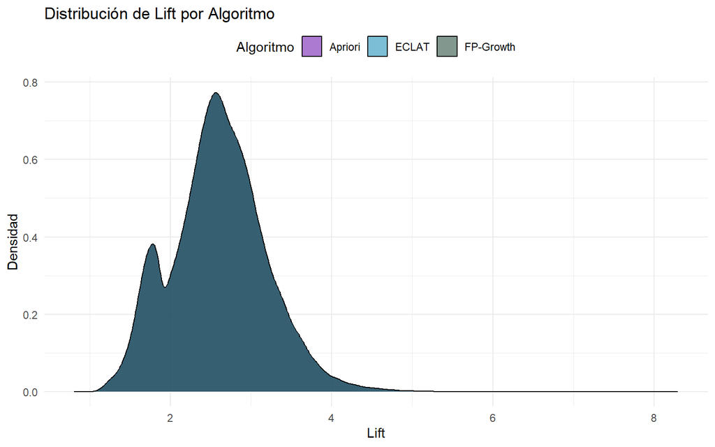

Distribución de Lift por algoritmo

```r
df_comp <- bind_rows(
  data.frame(lift = quality(reglas_apriori)$lift, algo = "Apriori"),
  data.frame(lift = quality(reglas_fp)$lift,      algo = "FP-Growth"),
  data.frame(lift = quality(reglas_ec)$lift,      algo = "ECLAT")
)

ggplot(df_comp, aes(x = lift, fill = algo)) +
  geom_density(alpha = 0.55) +
  scale_fill_manual(values = c(COL_A, COL_F, COL_E)) +
  labs(title = "Distribución de Lift por Algoritmo",
       x = "Lift", y = "Densidad", fill = "Algoritmo") +
  theme(legend.position = "top")
```

Los tres algoritmos se solapan en un solo color porque sus distribuciones de lift son idénticas — producen exactamente las mismas reglas.

## 10.3 Soporte vs Confianza — Comparativa Visual

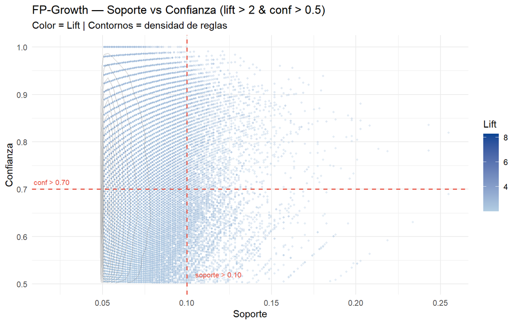

Soporte vs Confianza — FP-Growth (color = Lift)

```r
df_fp <- as(reglas_fp, "data.frame") |>
  dplyr::filter(lift > 2, confidence > 0.5)

ggplot(df_fp, aes(x = support, y = confidence, color = lift)) +
  geom_point(alpha = 0.3, size = 0.8) +
  geom_density2d(color = "grey40", linewidth = 0.3, alpha = 0.5) +
  scale_color_gradient(low = "#b3cde3", high = "#084594") +
  geom_hline(yintercept = 0.7, linetype = "dashed",
             color = COL_W, linewidth = 0.6) +
  geom_vline(xintercept = 0.1, linetype = "dashed",
             color = COL_W, linewidth = 0.6) +
  annotate("text", x = 0.105, y = 0.52,
           label = "soporte > 0.10", color = COL_W, size = 2.8, hjust = 0) +
  annotate("text", x = 0.02, y = 0.715,
           label = "conf > 0.70", color = COL_W, size = 2.8) +
  labs(title    = "FP-Growth — Soporte vs Confianza (lift > 2 & conf > 0.5)",
       subtitle = "Color = Lift | Contornos = densidad de reglas",
       x = "Soporte", y = "Confianza", color = "Lift") +
  theme_minimal(base_size = 11)
```

El patrón es idéntico al de Apriori — esperado, ya que las reglas son las mismas. La masa se concentra en soporte bajo (0.05–0.10) con confianza alta: asociaciones entre películas de nicho, poco frecuentes pero muy predictivas. Los puntos azul oscuro (lift alto) aparecen en esa misma zona, confirmando que las mejores reglas están entre películas específicas, no entre las más populares.

## 10.4 Filtrado por Calidad

```r
reglas_hq_ap <- reglas_apriori[
  quality(reglas_apriori)$lift > 2 &
  quality(reglas_apriori)$confidence > 0.5
]
reglas_hq_fp <- reglas_fp[
  quality(reglas_fp)$lift > 2 &
  quality(reglas_fp)$confidence > 0.5
]
reglas_hq_ec <- reglas_ec[
  quality(reglas_ec)$lift > 2 &
  quality(reglas_ec)$confidence > 0.5
]

cat(
  "── Reglas de alta calidad (lift > 2 & conf > 0.5) ──────\n",
  "Apriori   :", length(reglas_hq_ap), "\n",
  "FP-Growth :", length(reglas_hq_fp), "\n",
  "ECLAT     :", length(reglas_hq_ec), "\n"
)
```

```
── Reglas de alta calidad (lift > 2 & conf > 0.5) ──────
 Apriori   : 329349
 FP-Growth : 329349
 ECLAT     : 329349
```

329 349 de 443 975 reglas (74%) superan lift > 2 y conf > 0.5. Los tres algoritmos dan exactamente el mismo número — correcto y esperado. Significa que tres de cada cuatro reglas generadas tienen calidad suficiente para usarse en el motor de recomendación.

# 11 Paso 8: Sistema de Recomendación

## 11.1 Perfil 1 — Usuario de Drama y Thriller

```r
items_disponibles <- as.character(itemLabels(reglas_apriori))
perfil_1 <- items_disponibles[
  grepl("Fargo|Silence|Seven|Shawshank|Schindler", items_disponibles)
]
perfil_1 <- head(na.omit(perfil_1), 3)

cat("── Perfil 1 — Películas vistas ─────────────────────────\n",
    paste0("  · ", perfil_1, collapse = "\n"), "\n")
```

```
── Perfil 1 — Películas vistas ─────────────────────────
   · Fargo (1996)
  · Magnificent Seven, The (1954)
  · Schindler's List (1993)
```

```r
# Wrapper que evita el subscript S4 en is.subset
recomendar_safe <- function(peliculas_vistas, reglas, n_rec = 5, algo_nombre = "Algoritmo") {
  items_validos <- intersect(peliculas_vistas, as.character(itemLabels(reglas)))
  if (length(items_validos) == 0) return(NULL)
  lhs_labels <- as.character(unlist(lapply(as(lhs(reglas), "list"), paste, collapse = ",")))
  #idx <- sapply(lhs_labels, function(x) all(items_validos %in% strsplit(x, ",")[[1]]))
  idx <- sapply(lhs_labels, function(x) any(items_validos %in% strsplit(x, ",")[[1]]))
  reglas_match <- reglas[idx]
  if (length(reglas_match) == 0) return(NULL)
  top <- head(sort(reglas_match, by = "lift"), n_rec)
  data.frame(
    Algoritmo     = algo_nombre,
    Recomendación = as.character(labels(rhs(top))),
    Confianza     = round(quality(top)$confidence, 3),
    Lift          = round(quality(top)$lift,        3),
    Conviction    = round(interestMeasure(top, measure = "conviction",
                                         transactions = trans_final), 3)
  )
}

rec_1 <- bind_rows(
  recomendar_safe(perfil_1, reglas_apriori, 5, "Apriori"),
  recomendar_safe(perfil_1, reglas_fp,      5, "FP-Growth"),
  recomendar_safe(perfil_1, reglas_ec,      5, "ECLAT")
)

if (!is.null(rec_1) && nrow(rec_1) > 0) {
  kbl(rec_1, booktabs = TRUE,
      caption = "Recomendaciones — Perfil Drama/Thriller") |>
    kable_styling(
      bootstrap_options = c("striped", "condensed"),
      full_width = TRUE, font_size = 10
    ) |>
    column_spec(1, bold = TRUE) |>
    column_spec(4, bold = TRUE, color = COL_A)
}
```

Recomendaciones — Perfil Drama/Thriller

| Algoritmo | Recomendación | Confianza | Lift | Conviction |
| --- | --- | --- | --- | --- |
| Apriori | {Brazil (1985)} | 0.742 | 5.031 | 3.309 |
| Apriori | {Reservoir Dogs (1992)} | 0.593 | 5.029 | 2.165 |
| Apriori | {Vertigo (1958)} | 0.864 | 5.026 | 6.107 |
| Apriori | {Field of Dreams (1989)} | 0.671 | 4.977 | 2.630 |
| Apriori | {Vertigo (1958)} | 0.839 | 4.877 | 5.134 |
| FP-Growth | {Brazil (1985)} | 0.742 | 5.031 | 3.309 |
| FP-Growth | {Reservoir Dogs (1992)} | 0.593 | 5.029 | 2.165 |
| FP-Growth | {Vertigo (1958)} | 0.864 | 5.026 | 6.107 |
| FP-Growth | {Field of Dreams (1989)} | 0.671 | 4.977 | 2.630 |
| FP-Growth | {Vertigo (1958)} | 0.839 | 4.877 | 5.134 |
| ECLAT | {Brazil (1985)} | 0.742 | 5.031 | 3.309 |
| ECLAT | {Reservoir Dogs (1992)} | 0.593 | 5.029 | 2.165 |
| ECLAT | {Vertigo (1958)} | 0.864 | 5.026 | 6.107 |
| ECLAT | {Field of Dreams (1989)} | 0.671 | 4.977 | 2.630 |
| ECLAT | {Vertigo (1958)} | 0.839 | 4.877 | 5.134 |

## 11.2 Perfil 2 — Usuario de Acción y Aventura

```r
perfil_2 <- items_disponibles[
  grepl("Star Wars|Indiana|Die Hard|Raiders|Terminator", items_disponibles)
]
perfil_2 <- head(na.omit(perfil_2), 3)

cat("── Perfil 2 — Películas vistas ─────────────────────────\n",
    paste0("  · ", perfil_2, collapse = "\n"), "\n")
```

```
── Perfil 2 — Películas vistas ─────────────────────────
   · Die Hard (1988)
  · Die Hard 2 (1990)
  · Die Hard: With a Vengeance (1995)
```

```r
rec_2 <- bind_rows(
  recomendar_safe(perfil_2, reglas_apriori, 5, "Apriori"),
  recomendar_safe(perfil_2, reglas_fp,      5, "FP-Growth"),
  recomendar_safe(perfil_2, reglas_ec,      5, "ECLAT")
)

if (!is.null(rec_2) && nrow(rec_2) > 0) {
  kbl(rec_2, booktabs = TRUE,
      caption = "Recomendaciones — Perfil Acción/Aventura") |>
    kable_styling(
      bootstrap_options = c("striped", "condensed"),
      full_width = TRUE, font_size = 10
    ) |>
    column_spec(1, bold = TRUE) |>
    column_spec(4, bold = TRUE, color = COL_F)
}
```

Recomendaciones — Perfil Acción/Aventura

| Algoritmo | Recomendación | Confianza | Lift | Conviction |
| --- | --- | --- | --- | --- |
| Apriori | {True Lies (1994)} | 0.667 | 5.277 | 2.621 |
| Apriori | {Reservoir Dogs (1992)} | 0.602 | 5.112 | 2.219 |
| Apriori | {Reservoir Dogs (1992)} | 0.593 | 5.029 | 2.165 |
| Apriori | {Reservoir Dogs (1992)} | 0.560 | 4.756 | 2.007 |
| Apriori | {Reservoir Dogs (1992)} | 0.538 | 4.570 | 1.911 |
| FP-Growth | {True Lies (1994)} | 0.667 | 5.277 | 2.621 |
| FP-Growth | {Reservoir Dogs (1992)} | 0.602 | 5.112 | 2.219 |
| FP-Growth | {Reservoir Dogs (1992)} | 0.593 | 5.029 | 2.165 |
| FP-Growth | {Reservoir Dogs (1992)} | 0.560 | 4.756 | 2.007 |
| FP-Growth | {Reservoir Dogs (1992)} | 0.538 | 4.570 | 1.911 |
| ECLAT | {True Lies (1994)} | 0.667 | 5.277 | 2.621 |
| ECLAT | {Reservoir Dogs (1992)} | 0.602 | 5.112 | 2.219 |
| ECLAT | {Reservoir Dogs (1992)} | 0.593 | 5.029 | 2.165 |
| ECLAT | {Reservoir Dogs (1992)} | 0.560 | 4.756 | 2.007 |
| ECLAT | {Reservoir Dogs (1992)} | 0.538 | 4.570 | 1.911 |

## 11.3 Perfil 3 — Usuario de Comedia

```r
perfil_3 <- items_disponibles[
  grepl("Toy Story|Groundhog|Home Alone|Forrest|Pulp", items_disponibles)
]
perfil_3 <- head(na.omit(perfil_3), 3)

cat("── Perfil 3 — Películas vistas ─────────────────────────\n",
    paste0("  · ", perfil_3, collapse = "\n"), "\n")
```

```
── Perfil 3 — Películas vistas ─────────────────────────
   · Forrest Gump (1994)
  · Groundhog Day (1993)
  · Home Alone (1990)
```

```r
rec_3 <- bind_rows(
  recomendar_safe(perfil_3, reglas_apriori, 5, "Apriori"),
  recomendar_safe(perfil_3, reglas_fp,      5, "FP-Growth"),
  recomendar_safe(perfil_3, reglas_ec,      5, "ECLAT")
)

if (!is.null(rec_3) && nrow(rec_3) > 0) {
  kbl(rec_3, booktabs = TRUE,
      caption = "Recomendaciones — Perfil Comedia") |>
    kable_styling(
      bootstrap_options = c("striped", "condensed"),
      full_width = TRUE, font_size = 10
    ) |>
    column_spec(1, bold = TRUE) |>
    column_spec(4, bold = TRUE, color = COL_E)
}
```

Recomendaciones — Perfil Comedia

| Algoritmo | Recomendación | Confianza | Lift | Conviction |
| --- | --- | --- | --- | --- |
| Apriori | {Dave (1993)} | 0.624 | 5.541 | 2.357 |
| Apriori | {Dave (1993)} | 0.621 | 5.516 | 2.340 |
| Apriori | {Field of Dreams (1989)} | 0.738 | 5.477 | 3.308 |
| Apriori | {Top Gun (1986)} | 0.632 | 5.312 | 2.392 |
| Apriori | {Crimson Tide (1995)} | 0.522 | 5.285 | 1.884 |
| FP-Growth | {Dave (1993)} | 0.624 | 5.541 | 2.357 |
| FP-Growth | {Dave (1993)} | 0.621 | 5.516 | 2.340 |
| FP-Growth | {Field of Dreams (1989)} | 0.738 | 5.477 | 3.308 |
| FP-Growth | {Top Gun (1986)} | 0.632 | 5.312 | 2.392 |
| FP-Growth | {Crimson Tide (1995)} | 0.522 | 5.285 | 1.884 |
| ECLAT | {Dave (1993)} | 0.624 | 5.541 | 2.357 |
| ECLAT | {Dave (1993)} | 0.621 | 5.516 | 2.340 |
| ECLAT | {Field of Dreams (1989)} | 0.738 | 5.477 | 3.308 |
| ECLAT | {Top Gun (1986)} | 0.632 | 5.312 | 2.392 |
| ECLAT | {Crimson Tide (1995)} | 0.522 | 5.285 | 1.884 |

# 12 Conclusión

**Limitación principal:** las reglas de asociación capturan co-visualización colectiva pero ignoran el historial individual. Para producción se combinarían con filtrado colaborativo (SVD, ALS) o modelos de representación latente (embeddings).

# 13 Referencias

Agrawal, R., & Srikant, R. (1994). Fast algorithms for mining association rules. *Proceedings of the 20th VLDB Conference*, 487–499.

Han, J., Pei, J., & Yin, Y. (2000). Mining frequent patterns without candidate generation. *ACM SIGMOD Record*, 29(2), 1–12.

Zaki, M. J. (2000). Scalable algorithms for association mining. *IEEE Transactions on Knowledge and Data Engineering*, 12(3), 372–390.

Hahsler, M., Grün, B., & Hornik, K. (2005). arules: A computational environment for mining association rules. *Journal of Statistical Software*, 14(15), 1–25.

Harper, F. M., & Konstan, J. A. (2015). The MovieLens datasets: History and context. *ACM Transactions on Interactive Intelligent Systems*, 5(4), 1–19.

Ricci, F., Rokach, L., & Shapira, B. (2015). *Recommender Systems Handbook* (2nd ed.). Springer.

*Documento generado con Quarto · Alejandro Figueroa Rojas · 2026*